# Examples using chart helper functions

2024-06-20

This document demonstrates example usage of `linechart` and `barchart` functions from `DBTPlotR`. These are designed for easy and quick to use, and require little knowledge of `ggplot2`.

Start by installing the `ggplot2` and `dbtplotr` packages. As `dbtplotr` is an internal package, we install it using the `devtools` package. We also install `DBI` to connect to datasets on Data Workspace, and`dplyr` to manipulate this data.

```r
req <- c("ggplot2", "DBI", "dplyr", "scales", "plotly")
to_install <- req[!(req %in% installed.packages()[,"Package"])]
if(length(to_install)) install.packages(to_install)

#devtools::install_git("git@gitlab.data.trade.gov.uk:dbt-data-visualisation-library/dbtplotr.git", upgrade = 'never')

source("../R/charts.R")

library(ggplot2); library(dbtplotr); library(dplyr); library(lubridate); library(DBI)
```

Load in a dummy dataset…

```r
conn <- dbConnect(RPostgres::Postgres())
tryCatch({
  res <- dbSendQuery(conn, "SELECT country, year_2000, year_2001, year_2002, year_2003, year_2004
                     FROM \"imf\".\"world_economic_outlook__by_country\"
                     where weo_subject_code = 'NGDPDPC'
                     and country in ('United Kingdom', 'United States','France','Germany')")
  while (!dbHasCompleted(res)) {
    chunk <- dbFetch(res, n = 10)
    print(chunk)
  }
  dbClearResult(res)
}, finally={
  dbDisconnect(conn)
})

data <-
  chunk %>%
  reshape2::melt() %>%
  mutate(year_of_calculation= gsub('year_', '',variable)) %>%
  select(country, year_of_calculation, value) %>%
  mutate(year_of_calculation = as.Date(year_of_calculation, format = '%Y')) %>%
  mutate(year_of_calculation = floor_date(year_of_calculation, 'year'))
```

### Example line chart

Let’s create a simple linechart to compare countries over time using the `linechart` function from `dbtplotr`.

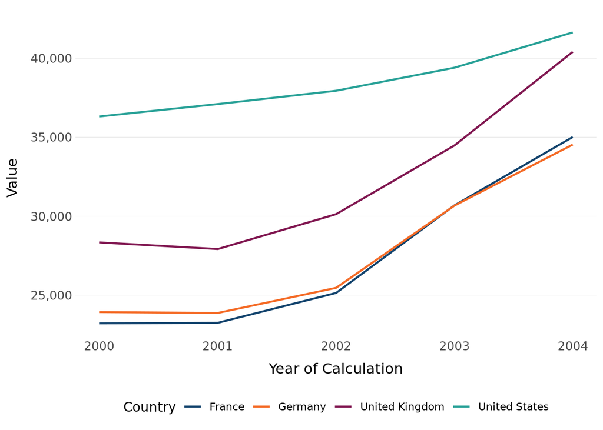

```r
linechart(data,
          x_axis= 'year_of_calculation',
          y_axis = 'value',
          group = 'country')
```

Add titles, subtitles, and customise axes labels using `+ labs()`. Axes titles can be removed within `+ theme()` using `element_blank()`.

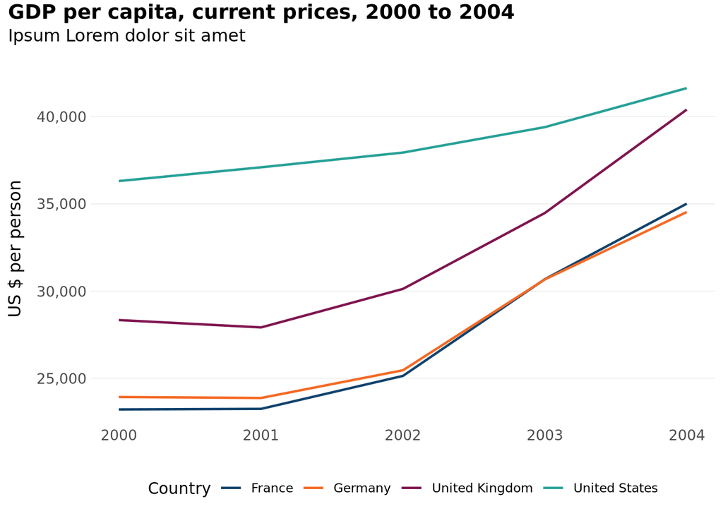

```r
linechart(data,
          x_axis= 'year_of_calculation',
          y_axis = 'value',
          group = 'country') +
  labs(title = "GDP per capita, current prices, 2000 to 2004",
       subtitle = "Ipsum Lorem dolor sit amet",
       y = "US $ per person") +
  theme(axis.title.x = element_blank())
```

The default colour palette used by DBTPlotR chart functions is the ONS analysis community colours, `gaf`. To select another colour palette, use `+ colours_dbt()` specifying your chart type and chosen palette. See the full list of palettes available through DBTPlotR [here](https://gitlab.data.trade.gov.uk/dbt-data-visualisation-library/dbtplotr#colour-palettes).

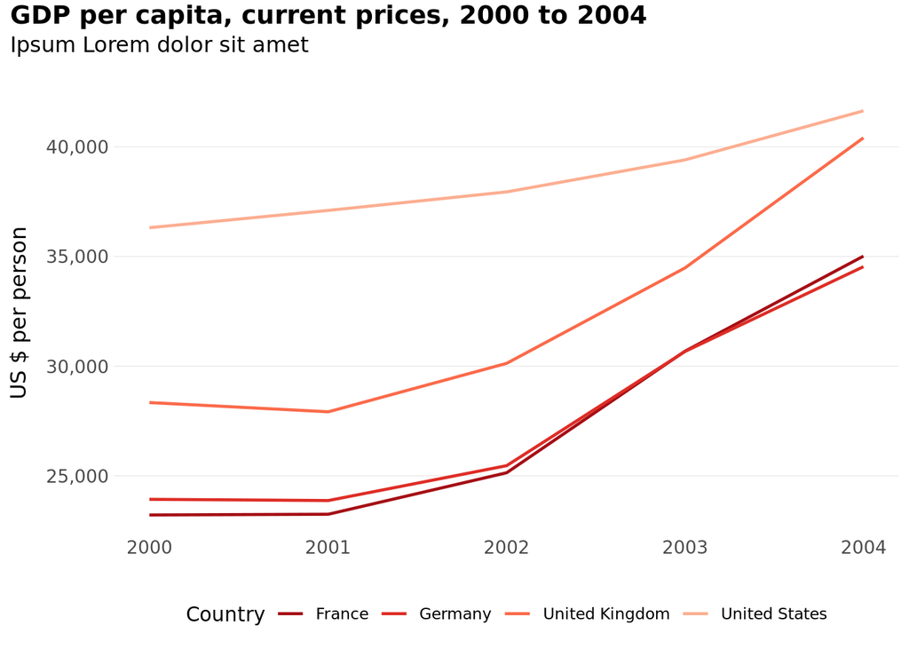

```r
linechart(data,
          x_axis= 'year_of_calculation',
          y_axis = 'value',
          group = 'country') +
  labs(title = "GDP per capita, current prices, 2000 to 2004",
       subtitle = "Ipsum Lorem dolor sit amet",
       y = "US $ per person") +
  theme(axis.title.x = element_blank()) +
  colours_dbt(type = 'line', palette = 'reds')
```

To create a barchart, use the `barchart` function from `dbtplotr`.

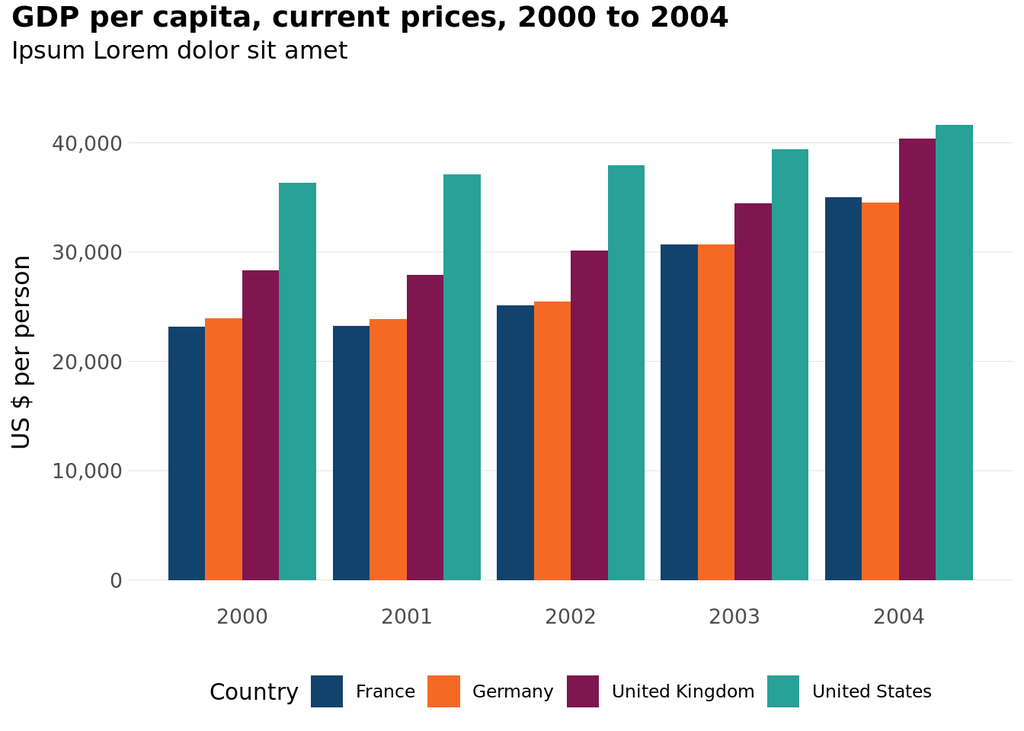

```r
barchart(data,
         x_axis = 'year_of_calculation',
         y_axis = 'value',
         group = 'country') +
  labs(title = "GDP per capita, current prices, 2000 to 2004",
       subtitle = "Ipsum Lorem dolor sit amet",
       y = "US $ per person") +
  theme(axis.title.x = element_blank())
```

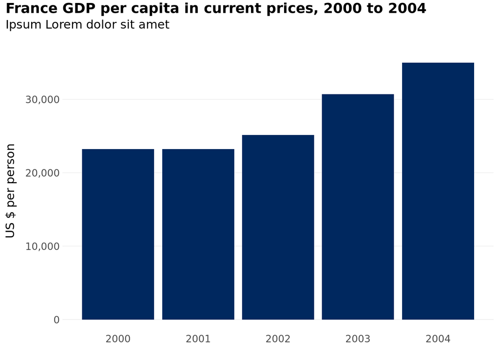

```r
barchart(data %>% filter(country == 'France'),
         x_axis = 'year_of_calculation',
         y_axis = 'value')  +
  labs(title = "France GDP per capita in current prices, 2000 to 2004",
       subtitle = "Ipsum Lorem dolor sit amet",
       y = "US $ per person") +
  theme(axis.title.x = element_blank())
```

Switch the x- and y- axes by setting `flip = TRUE`.

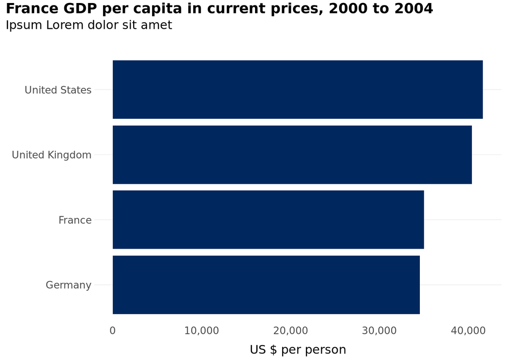

```r
barchart(data %>% filter(year_of_calculation == '2004-01-01'),
         x_axis = 'country',
         y_axis = 'value',
         flip = T)  +
  labs(title = "France GDP per capita in current prices, 2000 to 2004",
       subtitle = "Ipsum Lorem dolor sit amet",
       y = "US $ per person") +
  theme(axis.title.y = element_blank())
```